# Assignment 4

Maya Stein

2025-11-21

# Set Up

Load the libraries

```
library(tidyverse)
library(dplyr)
library(psymetadata)
```

Look at the data set

```
?barroso2021
```

[output not shown]

[output cut: 737 more lines]

First I will explore the number of students with low vs high math ability per each grade

[output not shown]

It seems there are no students identified as having low math ability in grades 1, 3, 4, and 6. Now I will confirm if this is accurate

[output not shown]

Assess grades 2 and 5

[output not shown]

I now need to observe the sample size for each grade

```
barroso2021 |>
  group_by(grade) |>
  summarize(n=n())
```

| grade | n |
| --- | --- |
| 1 | 68 |
| 2 | 89 |
| 3 | 116 |
| 4 | 99 |
| 5 | 355 |
| 6 | 20 |

Grade 5 has the biggest sample, as well as students for both high and low math ability conditions. Grade 6 has the lowest sample size, which likely explains the lack of samples for students with low math abilities. The absence/presence of low math ability students in the other grades is not well understood at this time. This will likely play a role in observations of effect size.

I will now look at the range of effect sizes (absolute values of effect size) No effect = > 0.0, < 0.2 Small effect = >= 0.2, < 0.5 Medium effect = >=0.5, <0.8 Large effect = >0.8

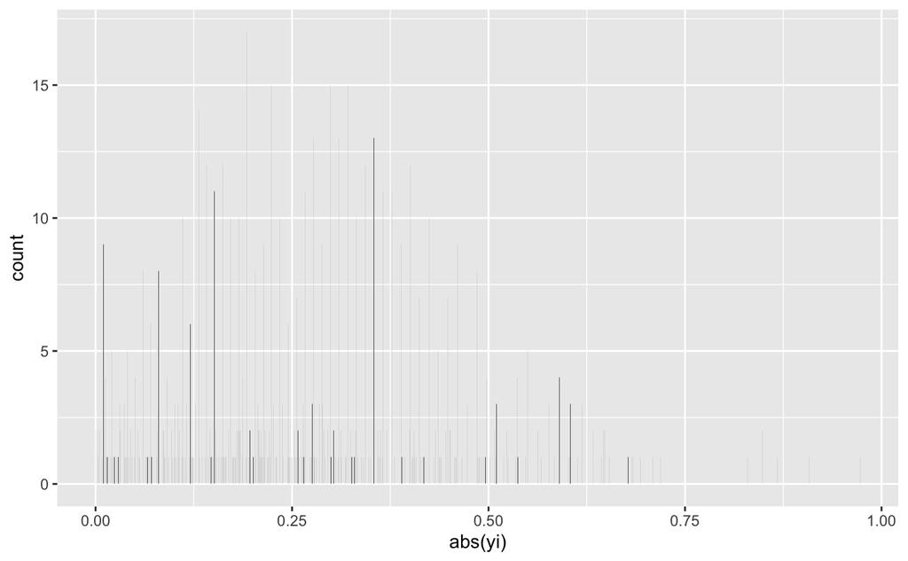

Now I am going to group effect sizes based on the magnitude of their absolute value

Now I will observe the distribution of effect sizes

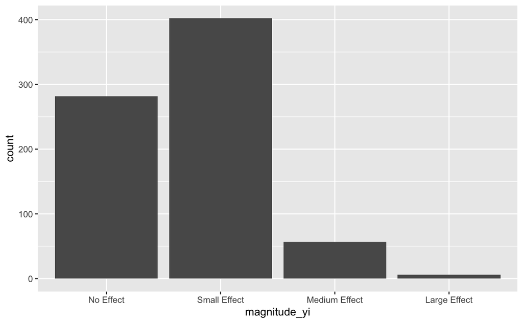

# Visualizations

Sample size for low/high math ability distributed by grade

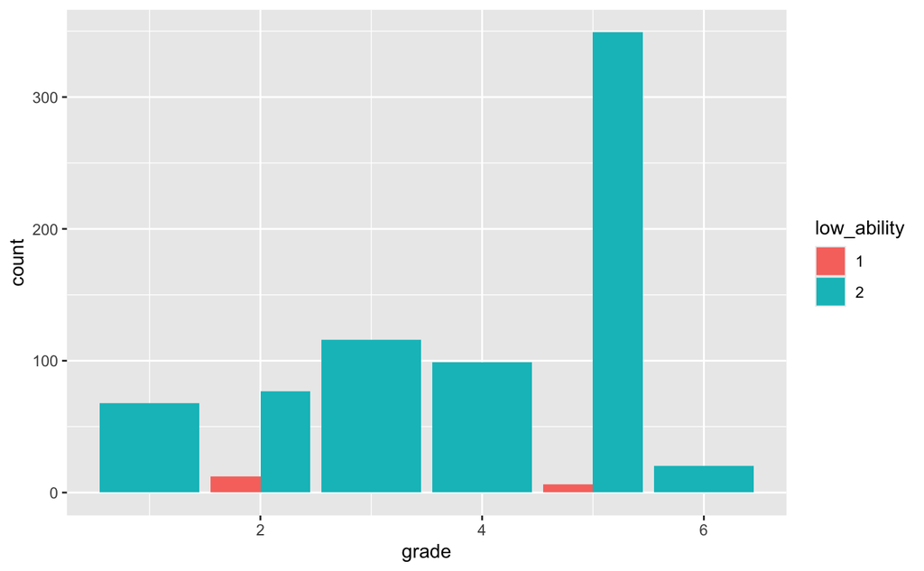

Effect size distributed by grade

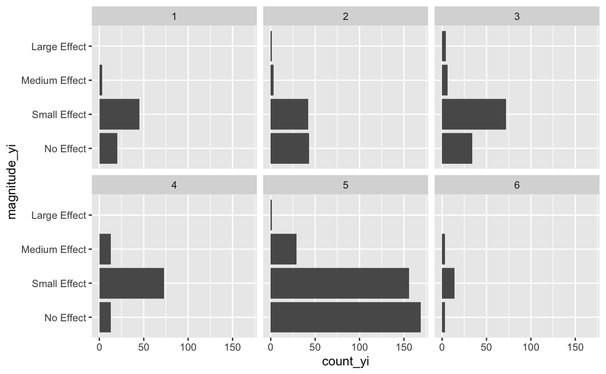

Effect size distributed by grade - low vs high math ability for grades 2 and 5

[output not shown]